# Business Analysis - Victor Isakov

Intro:

The problem of our business is to identify if sustainable wedding vendors are more cost effective. The main stakeholders are vendors and customers.

Sustainable Wedding Vendors - practice wedding activities/provide products and/or services that do less harm to ecology, people around, and support economy's vitality. (UCLA)

Being Cost Effective - providing good value for the amount of money paid.(Cambridge Dictionary, 2023)

How we measure Cost Effectiveness in our Wedding Database: we identify if customer satisfaction (Rating) by a product/service is worth the money paid. In our case, we compare if paying more (by customer) will provide them with a higher value. (Indeed, 2022)

Based on the definition of key terms, we can underline what we need to know: If sustainable vendors provide higher value for the same amount of money as non-sustainable vendors.And we will answer it by assessing relationship of Price of the products/services compared to Sustainable Practices as well as Rating of a product/service that vendors provide.

Answer:

To answer the business question, correlation between price per unit and sustainability has given the biggest answer of 0.15, which is considered a weak positive correlation. Further, when doing OLS model test of Vendor Rating to Vendor Sustainability, the results showed p-value less than 0.05 which suggested statistical significance of the relationship. In addition, I have completed another OLS model analysis between Price per Unit and Vendor Rating, which also had a p-value less than 0.05 and suggested a statistically significant relationship between these values.

It means, that increase in Rating leads to decrease in Sustainability. Also, increase in Price per Unit decreases Rating. And as we see in 2 histograms where Sustainable products/services are more expensive on average than Non-Sustainable ones, we can answer that Sustainable Vendors that sell sustainable products/services cost more than Non-Sustainable ones. And when they increase in price per unit, there is a correlation that customers will have a lower rating for the service/product they receive.

The outcome, Vendors with Sustainable practices are Not more cost effective due to lower customer satisfaction and higher price.

Top two actionable insights:

1. Vendors should leverage information from this dataset and focus more on customer satisfaction which will provide them with higher returns and bring higher value to both - customers and vendors. Focusing on the quality of service/product rather than sustainability will lead to better results. (Gulanti and James, 2005) This dataset shows the affect of rating on cost effectiveness which should be utilized by vendors.
2. Having lower prices for sustainable practices might increase customers' interest in getting that service and could impact more than just one company or a group of individuals. Decreased prices for Sustainable services will lower the threshold to entry by customers, which will lead to democratization of such service and potentially higher customer satisfaction and environmental impact. As price is considered a barrier for 41% of customers to buy a sustainable product. (Pieters et al, 2022) Dataset discovered higher price of Sustainable products/services which should be leveraged for vendors.

References:

Cost-effective. (2023). https://dictionary.cambridge.org/us/dictionary/english/cost-effective

Grand Canyon University. “5 Reasons Why Consumer Research Matters to Your Business.” GCU, 3 Oct. 2018, www.gcu.edu/blog/business-management/5-reasons-why-consumer-research-matters-your-business.

Gulati, Ranjay, and James, B. Oldroyd. “The Quest for Customer Focus.” Harvard Business Review, Apr. 2005, hbr.org/2005/04/the-quest-for-customer-focus.

Pieters, Leon, et al. “The Cost of Buying Green.” Deloitte Insights, 17 June 2022, www2.deloitte.com/us/en/insights/industry/retail-distribution/consumer-behavior-trends-state-of-the-consumer-tracker/sustainable-products-and-practices-for-green-living.html.

“What Is Customer Value? (and How to Use It).” Indeed Career Guide, 4 Oct. 2022, www.indeed.com/career-advice/career-development/customer-value.

What is Sustainability? | UCLA Sustainability. (n.d.). UCLA Sustainability. https://www.sustain.ucla.edu/what-is-sustainability/ __________________________________________ ___________________________________________ ________________________________________________

```python
# importing packages that will be necessary
import pandas            as pd
import matplotlib.pyplot as plt
import seaborn           as sns
from scipy.stats import chi2_contingency
import warnings

# Suppress all warnings
warnings.filterwarnings("ignore")
# specifying a file name
file = "vendors_info.xlsx"

# reading the file in Python through pandas
vendors_info = pd.read_excel(io         = file,
                     sheet_name = 'vendors_info',
                     header     = 0     )

# outputting the first 5 rows of the dataset to check that it works
vendors_info.head(n=5)
```

|  | vendor_id | product_id | vendor_depart | vendor_name | vendor_location | vendor_sustainable | vendor_rating | price_unit | price_ce |
| --- | --- | --- | --- | --- | --- | --- | --- | --- | --- |
| 0 | ven_01 | prod_001 | venues | the bridges golf club | san ramon | 1 | 48 | 14000.0 | 2 |
| 1 | ven_02 | prod_002 | venues | viaggio estate and winery | acampo | 1 | 41 | 9500.0 | 1 |
| 2 | ven_03 | prod_003 | venues | leal vineyards | hollister | 1 | 48 | 27000.0 | 2 |
| 3 | ven_04 | prod_004 | venues | oceano hotel and spa | half moon bay | 1 | 49 | 16000.0 | 2 |
| 4 | ven_05 | prod_005 | venues | log cabin at the presidio | san francisco | 1 | 48 | 24000.0 | 2 |

```python
# finding descriptive statistics
vendors_info.describe()
```

|  | vendor_sustainable | vendor_rating | price_unit | price_ce |
| --- | --- | --- | --- | --- |
| count | 850.000000 | 850.000000 | 850.000000 | 850.000000 |
| mean | 0.527059 | 38.190588 | 1334.604753 | 2.322353 |
| std | 0.499561 | 19.782776 | 3820.439323 | 1.089448 |
| min | 0.000000 | 0.000000 | 0.520000 | 1.000000 |
| 25% | 0.000000 | 40.000000 | 90.000000 | 1.000000 |
| 50% | 1.000000 | 49.000000 | 175.000000 | 2.000000 |
| 75% | 1.000000 | 50.000000 | 400.000000 | 3.000000 |
| max | 1.000000 | 50.000000 | 32000.000000 | 4.000000 |

```python
vendors_corr = vendors_info.corr(method = "pearson",
                 numeric_only = True)
vendors_corr
```

|  | vendor_sustainable | vendor_rating | price_unit | price_ce |
| --- | --- | --- | --- | --- |
| vendor_sustainable | 1.000000 | 0.011277 | 0.154899 | 0.122463 |
| vendor_rating | 0.011277 | 1.000000 | 0.062425 | -0.058161 |
| price_unit | 0.154899 | 0.062425 | 1.000000 | 0.129534 |
| price_ce | 0.122463 | -0.058161 | 0.129534 | 1.000000 |

Strongest Correlations with sustainability are between price_unit (which is price per unit) and price_ce (which is price index on scale from 1 - cheap to 4 - expensive). It shows that there is a weak positive correlation of 0.155 and 0.122. It suggests that price is affected by sustainability.

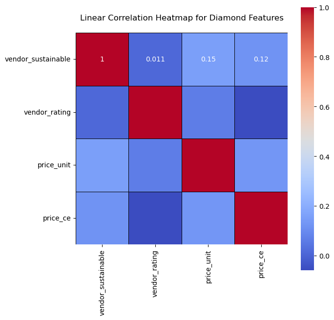

```python
# creating correlations within the dataset
vendors_corr = vendors_info.corr(method = "pearson",
                 numeric_only = True)

# displaying the plot
fig, ax = plt.subplots( figsize = (7 , 7) )


# developing a heatmap
sns.heatmap(data       = vendors_corr, # the correlation matrix
            cmap       = 'coolwarm'        , # changing to MEDIUM colors
            square     = True         , # tightening the layout
            annot      = True         , # should there be numbers in the heatmap
            linecolor  = 'black'      , # lines between boxes
            linewidths = 0.5          ) # how thick should the lines be?


# title and displaying the plot
plt.title(label = """
Linear Correlation Heatmap for Diamond Features
""")


# visualizing the data of the correlation
plt.show(block = True)
```

The heatmap above is a good visualization of best correlations in the dataset.

```python
#Citation: https://www.pythonfordatascience.org/chi-square-test-of-independence-python/

# setting the contigency table
cont_table = pd.crosstab(vendors_info['vendor_depart'], vendors_info['vendor_sustainable'])

# performing the chi-squared test, finding p-value, degrees of freedom, and expected frequency table
chi2, p_value, dof, expected_freq = chi2_contingency(cont_table)

# displaying the results
print("Contingency Table:\n\n", cont_table)
print("\nChi-Squared Statistic:", chi2.round(decimals=2))
print("P-value:", p_value)
print("Degrees of Freedom:", dof)
print("\nExpected Frequencies:\n", expected_freq.round(decimals=2))
```

```
Contingency Table:

 vendor_sustainable    0    1
vendor_depart
catering              4   99
dress and attire     28   22
flowers              14   28
hair and makeup     277  114
invitations          18   32
jewelry              25   25
music                15   20
photo and video       1   48
rental                8   22
venues               12   38

Chi-Squared Statistic: 228.91
P-value: 2.791486687892773e-44
Degrees of Freedom: 9

Expected Frequencies:
 [[ 48.71  54.29]
 [ 23.65  26.35]
 [ 19.86  22.14]
 [184.92 206.08]
 [ 23.65  26.35]
 [ 23.65  26.35]
 [ 16.55  18.45]
 [ 23.17  25.83]
 [ 14.19  15.81]
 [ 23.65  26.35]]
```

Table above represents how many products each department sells that either have sustainable practices(index of 1) or don't (index of 0). This chi-squared test was performed to identify whether vendors are sustainable or not.

Also, it shows expected/predicted values for each departments, and in some departments it differs from the predictions. For example, Hair and Makeup department was predicted to have more sustainable products, but it is the opposite. Which states that in order to understand the business question deeper, there is a need to discuss each department's performance separately. Which requires potentially more samples, but we will go into other factors that help us answer business question.

Finally, low p-value shows a statistical significance that sustainability varies across different vendors.

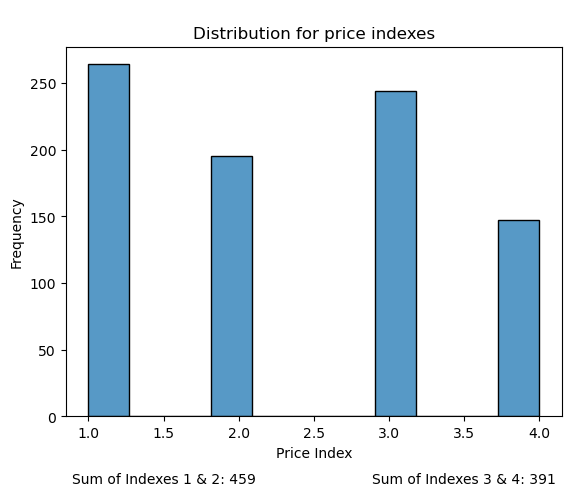

```python
# creating frequency plot
sns.histplot(data = vendors_info,
             x    = 'price_ce')


# title and labels of the plot
plt.title("""
Distribution for price indexes""")
plt.xlabel("Price Index")
plt.ylabel("Frequency")

#creating an object that will have values of price_ce indexes
price_ce_counts = vendors_info['price_ce'].value_counts()

# calculating sums of 1st and 2nd indexes, and same with 3rd and 4th
sum_1_2 = price_ce_counts.loc[1] + price_ce_counts.loc[2]
sum_3_4 = price_ce_counts.loc[3] + price_ce_counts.loc[4]

# adding sum of indexes at the bottom of the plot
plt.text(1.5, -50, f'Sum of Indexes 1 & 2: {sum_1_2}', horizontalalignment='center')
plt.text(3.5, -50, f'Sum of Indexes 3 & 4: {sum_3_4}', horizontalalignment='center')


# rendering the plot
plt.show()
```

The frequency plot above demonstrates number of products with indexes 1 through 4. We have identified indexes, where 1=cheap, 2=affordable, 3=moderate, 4=expensive. Based on price index we can identify in which category the product stays. There are more cheaper(1 & 2) products = 459, and less of more expensive ones(3 & 4) = 391. To find Cost Efficiency we still need to find rating of the vendor to understand the Performance.

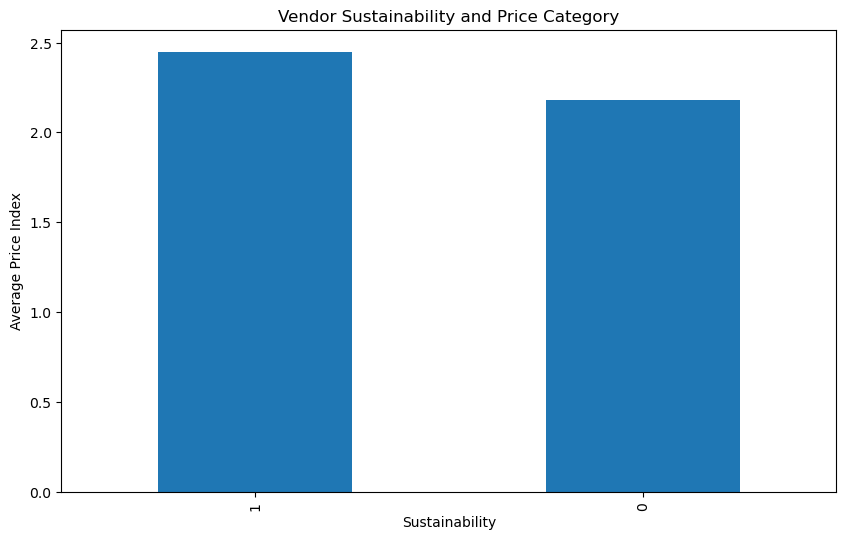

```python
#Citation: https://pandas.pydata.org/pandas-docs/version/0.25.0/reference/api/pandas.core.groupby.GroupBy.mean.html

# grouping by vendor_depart and calculating mean price_ce index
average_ratings = vendors_info.groupby('vendor_sustainable')['price_ce'].mean()

# sorting the results for a better visualization in ascending order
average_ratings_sorted = average_ratings.sort_values(ascending=False)

# plotting the results
plt.figure(figsize=(10, 6))
average_ratings_sorted.plot(kind='bar')
plt.title('Vendor Sustainability and Price Category')
plt.xlabel('Sustainability')
plt.ylabel('Average Price Index')
plt.show()
```

The plot above shows average price index based on sustainability index. It presents us with a side-by-side comparison of sustainable and non-sustainable average price index. As the outcome, we see more vendors that are sustainable with higher price index. So, sustainable vendors are more expensive but we still need to compare it to rating to make further conclusions.

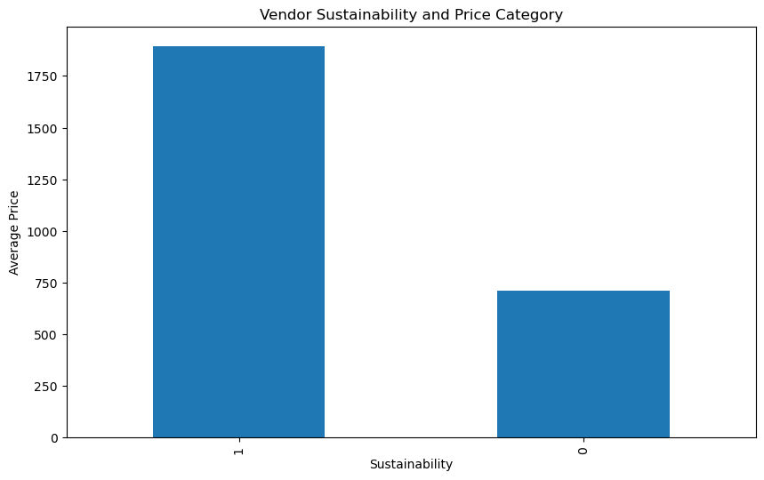

```python
#Citation: https://pandas.pydata.org/pandas-docs/version/0.25.0/reference/api/pandas.core.groupby.GroupBy.mean.html

# grouping by vendor_depart and calculating mean price_ce index
average_ratings = vendors_info.groupby('vendor_sustainable')['price_unit'].mean()

# sorting the results for a better visualization in ascending order
average_ratings_sorted = average_ratings.sort_values(ascending=False)

# plotting the results
plt.figure(figsize=(10, 6))
average_ratings_sorted.plot(kind='bar')
plt.title('Vendor Sustainability and Price Category')
plt.xlabel('Sustainability')
plt.ylabel('Average Price')
plt.show()
```

The plot above shows average price based on sustainability index. It presents us with a side-by-side comparison of sustainable and non-sustainable average price. As the outcome, we see more vendors that are sustainable with higher price. So, we support the previous statement above but we still need to make further calculations on Rating.

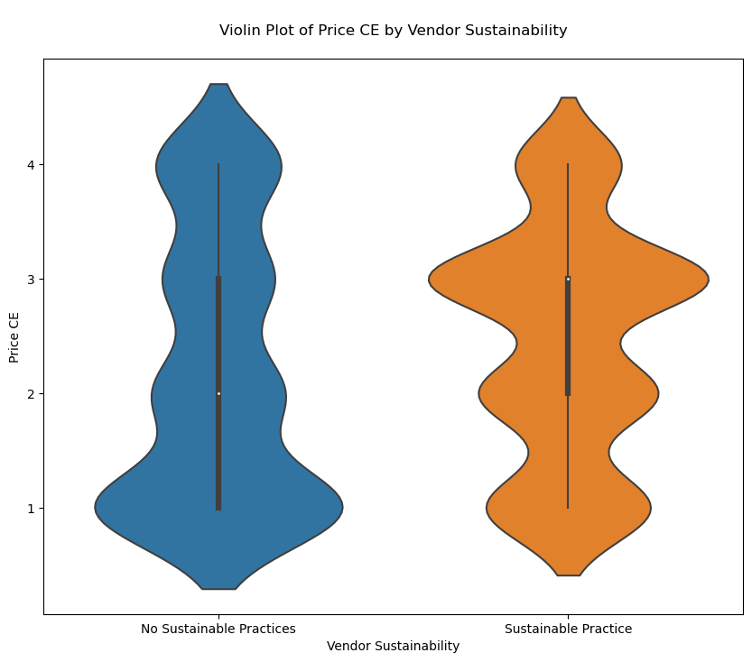

```python
# specifying plot size
fig, ax = plt.subplots(figsize=(10,8))

# creating a violin plot for price_ce by vendor_sustainable
sns.violinplot(x='vendor_sustainable',
               y='price_ce',
               data=vendors_info,
               split=True)

# formatting and displaying the plot
plt.title(label="""
Violin Plot of Price CE by Vendor Sustainability
""")
plt.xlabel(xlabel='Vendor Sustainability')
plt.ylabel(ylabel='Price CE')
plt.xticks([0, 1], ['No Sustainable Practices', 'Sustainable Practice'])

plt.show()
```

This violin plot helps to understand that there vendors with no sustainable practices have cheaper prices. Whereas vendors with sustainable practices show more higher prices.

In the part after next we will learn further relationship of Sustainability, Price Index and Rating.

```python
# creating frequency tables specifically for vendor_sustainable and price_ce
ftable_sust = vendors_info['vendor_sustainable'].value_counts()
ftable_ce = vendors_info['price_ce'].value_counts()

# outputting theese tables
ftable_sust, ftable_ce
```

```
(vendor_sustainable
 1    448
 0    402
 Name: count, dtype: int64,
 price_ce
 1    264
 3    244
 2    195
 4    147
 Name: count, dtype: int64)
```

The table above is a frequency table representing the number of sustainable vs non-sustainable products, and which price index appears more often than others. It simply provides us with more details about count of sustainable vendors vs not sustainable and how their price ranges.

```python
#Citation: https://pandas.pydata.org/pandas-docs/version/0.25.0/reference/api/pandas.core.groupby.GroupBy.mean.html


# filter out rows where price_unit, price_ce, and vendor_rating is 0 or NaN
filtered_vendors_info = vendors_info[
    (vendors_info['price_unit'] != 0) &
    (vendors_info['price_ce'] != 0) &
    (vendors_info['vendor_rating'] != 0)
].dropna(subset=['price_unit', 'price_ce', 'vendor_rating'])

# calculating mean values
mean_values = filtered_vendors_info.groupby('vendor_sustainable')[['price_unit', 'price_ce', 'vendor_rating']].mean().round(decimals=2)

# counting unique vendors based on vendor_id for both sustainable and not sustainable practices
unique_vend_sust = filtered_vendors_info[filtered_vendors_info['vendor_sustainable'] == 1]['vendor_id'].nunique()
unique_vend_not_sust = filtered_vendors_info[filtered_vendors_info['vendor_sustainable'] == 0]['vendor_id'].nunique()

# adding the count of unique vendors to the mean_values
mean_values['unique_vendors_count'] = [unique_vend_not_sust, unique_vend_sust]

mean_values
```

| vendor_sustainable | price_unit | price_ce | vendor_rating | unique_vendors_count |
| --- | --- | --- | --- | --- |
| 0 | 761.36 | 2.15 | 48.90 | 71 |
| 1 | 2107.69 | 2.41 | 47.52 | 174 |

The table above presents mean results of price per unit, price index, vendor rating, and the number of unique vendors that are sustainable.

The following pattern can be established:

Vendors with sustainable practices have higher price and price index, and at the same time they have slightly lower customer satisfaction (rating) which supports the idea that sustainable vendors are not bringing a higher value to customers.

Finding the means helps to understand that potentially, Vendors with No Sustainable practices bring same value for the lower amount of money which suggests that Sustainable Vendors are not more cost effective.

```python
# importing a package for Regression Model
import statsmodels.formula.api as smf

# setting values that will be in the model
lm_best = smf.ols(formula = """vendor_rating ~ vendor_sustainable+
                                          price_ce""",
                   data    = filtered_vendors_info)


# fitting the data into the model
results = lm_best.fit()


# creating summary
print(results.summary())
```

```
                            OLS Regression Results
==============================================================================
Dep. Variable:          vendor_rating   R-squared:                       0.037
Model:                            OLS   Adj. R-squared:                  0.035
Method:                 Least Squares   F-statistic:                     13.04
Date:                Wed, 08 Jan 2025   Prob (F-statistic):           2.78e-06
Time:                        15:52:40   Log-Likelihood:                -1798.9
No. Observations:                 674   AIC:                             3604.
Df Residuals:                     671   BIC:                             3617.
Df Model:                           2
Covariance Type:            nonrobust
======================================================================================
                         coef    std err          t      P>|t|      [0.025      0.975]
--------------------------------------------------------------------------------------
Intercept             48.8466      0.337    145.073      0.000      48.186      49.508
vendor_sustainable    -1.3859      0.272     -5.090      0.000      -1.921      -0.851
price_ce               0.0266      0.127      0.210      0.834      -0.222       0.275
==============================================================================
Omnibus:                      380.712   Durbin-Watson:                   1.054
Prob(Omnibus):                  0.000   Jarque-Bera (JB):             2816.874
Skew:                          -2.487   Prob(JB):                         0.00
Kurtosis:                      11.692   Cond. No.                         7.52
==============================================================================

Notes:
[1] Standard Errors assume that the covariance matrix of the errors is correctly specified.
```

The OLS Regression model explains only 3.7% of the relationship.

P-value for vendor sustainability index to rating is below 0.05 which suggests that there is a statistically significant relationship. P-value for vendor rating and price index is much higher than 0.05 which suggests there might be a random association rather than a real effect.

Finally, this OLS Model suggests there is no significant relation of price index to rating, so we need to do another relationship model analysis in the next step.

```python
# importing a package for Regression Model
import statsmodels.formula.api as smf

# setting values that will be in the model
lm_best = smf.ols(formula = """ price_unit ~ vendor_rating
                                         """,
                   data    = filtered_vendors_info)


# fitting the data into the model
results = lm_best.fit()


# creating summary
print(results.summary())
```

```
                            OLS Regression Results
==============================================================================
Dep. Variable:             price_unit   R-squared:                       0.008
Model:                            OLS   Adj. R-squared:                  0.007
Method:                 Least Squares   F-statistic:                     5.441
Date:                Wed, 08 Jan 2025   Prob (F-statistic):             0.0200
Time:                        15:52:40   Log-Likelihood:                -6543.4
No. Observations:                 674   AIC:                         1.309e+04
Df Residuals:                     672   BIC:                         1.310e+04
Df Model:                           1
Covariance Type:            nonrobust
=================================================================================
                    coef    std err          t      P>|t|      [0.025      0.975]
---------------------------------------------------------------------------------
Intercept      6334.0067   2084.743      3.038      0.002    2240.614    1.04e+04
vendor_rating  -100.6898     43.167     -2.333      0.020    -185.449     -15.931
==============================================================================
Omnibus:                      654.963   Durbin-Watson:                   0.748
Prob(Omnibus):                  0.000   Jarque-Bera (JB):            18134.917
Skew:                           4.598   Prob(JB):                         0.00
Kurtosis:                      26.689   Cond. No.                         656.
==============================================================================

Notes:
[1] Standard Errors assume that the covariance matrix of the errors is correctly specified.
```

This model suggests there is a statistically significant relationship between price per unit and vendor rating. It suggests that as price increases, the rating decreases.

It supports the idea that more expensive products provided by vendors give less cost effectiveness to the customer. This final OLS model finalized a weak but significant relation of decrease of cost effectiveness with price increase.